# Maximum Likelihood Estimates

UNC EPID 722: Dr. Steve Cole

February 2, 2016

*NOTE: ALL SAS code below copied from 2016 EPID 722 lecture material. SAS code based on Steve Cole’s programs titled, “program1.15dec15.sas”, “program2.15dec15.sas”, and “program3.19jan16.sas”. R code is adapted to the SAS code and written by Ann Von Holle.*

## 0.1 Preliminaries

### 0.1.1 Specify packages for R

```r
  #install.packages(c("knitr", "foreign", "tableone", "nlme")) # Note: you only need to do this once. then only if you want updates.
  require(knitr)
  require(foreign)
#  require(plyr)
  require(tableone)
  require(nlme)
  require(ggplot2)
  set.seed(123) # set seed so you get same results each time you run.
```

## 0.2 Program 1: read in hividu.csv data – will need to correct the path + data handling.

### 0.2.1 SAS

```sas
*Set a directory pointer;
%LET dir = c:\temp;
libname mle "c:\temp";

*Read excel data file;
proc import out=a datafile="&dir\hividu.csv" dbms=csv replace; getnames=yes;

*Make new random id;
data a; set a;
    call streaminit(123);
    u=rand("uniform");
proc sort data=a; by u;

*Rename variables;
data mle.b; set a; by u; * Note: I added a permanent dir to make this word in .Rmd file;

* create delta, t and art variables;
    if eventtype=0 then do; delta=0; t=t; art=.; end; *Censored w/out ART;
    if eventtype=1 and dth=0 then do; delta=0; t=taidsdth; art=tarv; end; *Censored w/ART;
    if eventtype=1 and dth=1 then do; delta=1; t=taidsdth; art=tarv; end; *Event (AIDS or death) w/ART;

* FOLLOWUP NOTE: the following two lines seem redundant. Any reason for setting it up this way?;
    if eventtype=2 and arv=0 then do; delta=1; t=taidsdth; art=.; end; *Event w/out ART;
    if eventtype=2 and arv=1 then do; delta=1; t=taidsdth; art=.; end; *Event w/out ART, ART was after AIDS;

    if t>10 then do; *Admin censor at 10 years;
        t=10; delta=0;
        if art>10 then art=.;
    end;

    if t<10 and delta=0 then drop=1; else drop=0;
    id=_n_;
    idu=baseidu;
    white=1-black;
    age=ageatfda;
    cd4=cd4nadir;
    art=round(art, 0.001); *Round times to .001 of a year, or about 8h;
    t=round(t, 0.001);
    keep id idu white age cd4 drop delta art t;

*Save as flat ASCII file;
data _null_; set mle.b;
    file "&dir\hividu15dec15.dat";
    put id 1-4 idu 6 white 8 age 10-11 cd4 13-16 drop 18 delta 20 @22 art 6.3 @29 t 6.3;
run; quit; run;

proc contents data=mle.b; run;
proc means data=mle.b; var _numeric_; run;

* Export to .csv for use in R;
proc export data=mle.b outfile="c:\temp\hividu15dec15.csv" dbms=csv replace; run;
```

```
## The CONTENTS Procedure
##
## Data Set Name        MLE.B                         Observations          1164
## Member Type          DATA                          Variables             9
## Engine               V9                            Indexes               0
## Created              02/14/2016 14:11:20           Observation Length    72
## Last Modified        02/14/2016 14:11:20           Deleted Observations  0
## Protection                                         Compressed            NO
## Data Set Type                                      Sorted                NO
## Label
## Data Representation  WINDOWS_64
## Encoding             wlatin1  Western (Windows)
##
##
##       Engine/Host Dependent Information
##
## Data Set Page Size          65536
## Number of Data Set Pages    2
## First Data Page             1
## Max Obs per Page            908
## Obs in First Data Page      882
## Number of Data Set Repairs  0
## ExtendObsCounter            YES
## Filename                    c:\temp\b.sas7bdat
## Release Created             9.0401M1
## Host Created                X64_8PRO
##
##
##     Alphabetic List of Variables and Attributes
##
## #    Variable    Type    Len    Format     Informat
##
## 8    age         Num       8
## 3    art         Num       8
## 9    cd4         Num       8
## 2    delta       Num       8
## 4    drop        Num       8
## 5    id          Num       8
## 6    idu         Num       8
## 1    t           Num       8    BEST12.    BEST32.
## 7    white       Num       8
##
##
##
## The MEANS Procedure
##
## Variable       N            Mean         Std Dev         Minimum         Maximum
## --------------------------------------------------------------------------------
## t           1164       6.0907216       3.8234075       0.0030000      10.0000000
## delta       1164       0.4974227       0.5002083               0       1.0000000
## art          671       2.6120611       2.0495385       0.0330000       9.8100000
## drop        1164       0.1091065       0.3119068               0       1.0000000
## id          1164     582.5000000     336.1621632       1.0000000         1164.00
## idu         1164       0.3771478       0.4848807               0       1.0000000
## white       1164       0.4226804       0.4941978               0       1.0000000
## age         1164      36.4407216       8.1727327      17.0000000      73.0000000
## cd4         1164     393.5515464     263.9804344               0         1933.00
## --------------------------------------------------------------------------------
```

### 0.2.2 R

Read the data.

```r
#getwd() # get the working directory
a = read.csv("../../data/hividu.csv", header=T) # read in data. relative to the working directory go up however many levels and into 'data' folder to read data.
#a = read.csv("../data/hividu.csv", header=T) # Ignore. only for local run checking.

# Instead of "../../data/hividu.csv, can specify full path of data location. For example a path could be "c:\temp\hividu.csv"

class(a) # check type of object
```

```
## [1] "data.frame"
```

```r
head(a) # default is first six rows of data frame
```

```
##             t eventtype ageatfda BASEIDU black cd4nadir arv dth       tarv
## 1 0.002737851         2       48       0     1      695   1   1 1.53045859
## 2 0.002737851         2       35       1     1      251   1   1 3.39493498
## 3 0.010951403         2       28       0     1       18   0   1 0.01095140
## 4 0.016427105         2       46       1     0      465   1   1 0.91444216
## 5 0.016427105         2       31       0     1        8   0   1 0.01642711
## 6 0.019164956         2       45       1     1      205   1   1 3.10198494
##      taidsdth newid
## 1 0.002737851     1
## 2 0.002737851     2
## 3 0.010951403     3
## 4 0.016427105     4
## 5 0.016427105     5
## 6 0.019164956     6
```

```r
colnames(a) = tolower(colnames(a)) # make all column names lower case
```

Data handling.

```r
a$u = runif(nrow(a)) # new random id
a = a[order(a$u),] # order by random id
head(a) # check

a = within(a, {
  art = round(ifelse(eventtype==1, tarv, NA), 3) # no missing eventtype. round to 3 decimal places
  delta = ifelse(eventtype==2, 1,
                 ifelse(eventtype==1 & dth==1, 1,
                        ifelse(eventtype==1 & dth==0, 0,
                               ifelse(eventtype==0, 0, NA))))
  t = round(ifelse(eventtype==0, t, taidsdth), 3) # round to 3 decimal places

  delta[t>10] = 0 # admin censor at 10 years
  art[t>10 & art>10] = NA
  t[t>10] = 10

  drop = ifelse(t<10 & delta==0, 1, 0)
  id = 1:nrow(a)
  idu = baseidu
  white = 1-black
  age = ageatfda
  cd4 = cd4nadir
  }) # rename variables

summary(a)

keep.vars = c("t", "delta", "art", "drop", "id", "idu", "white", "age", "cd4")
b = a[,colnames(a) %in% keep.vars]

str(b) # check
summary(b[,keep.vars])
```

## 0.3 Program 2: Table 1 and Table 2

### 0.3.1 Table 1 continuous

#### 0.3.1.1 SAS

by IDU and overall

```sas
  libname mle "c:\temp";
  data a; set mle.b; run;

  *First 20 records;
  proc print data=a(obs=20) noobs;
    var id idu white age cd4 art drop delta t;
    title "First 20 records, WIHS IDU data";

  *Table 1, continuous;
  proc sort data=a; by idu;
  proc means data=a n median q1 q3 maxdec=1; by idu;
    var age cd4;
    title "Table 1, continuous variables, by IDU";
  proc means data=a n median q1 q3 maxdec=1;
    var age cd4;
    title "Table 1, continuous variables, overall";

  *Table 1, categorical;
  proc freq data=a;
    tables white*idu/norow nopercent;
    title "Table 1, categorical variables, by IDU";
  proc freq data=a;
    tables white;
    title "Table 1, categorical variables, overall";
run;
```

```
## First 20 records, WIHS IDU data
##
## id    idu    white    age     cd4     art     drop    delta               t
##
##  1     1       0       44     376     .         0       1             2.245
##  2     1       1       32     392     .         0       1             1.213
##  3     0       0       44     181    1.224      0       0                10
##  4     1       0       35     526     .         0       1              1.24
##  5     1       1       46     386     .         0       1             7.871
##  6     0       1       29     285    2.207      0       1             6.593
##  7     1       0       34     358     .         0       1             1.191
##  8     0       1       39     708    2.300      0       1             5.098
##  9     1       0       45     840     .         0       1             2.226
## 10     0       0       47     274     .         0       1             8.761
## 11     0       0       33     288     .         0       0                10
## 12     1       1       48     213    2.316      0       0                10
## 13     1       1       46     133    3.663      0       1             5.005
## 14     0       1       28     431     .         0       1             1.903
## 15     1       1       34    1095     .         0       1             1.862
## 16     0       0       40     234    1.188      0       0                10
## 17     0       1       26     477    1.684      0       0                10
## 18     0       1       29     352    8.531      0       0                10
## 19     0       1       38     338    0.841      0       1             1.339
## 20     0       0       20    1231     .         0       0                10
##
##
##
## Table 1, continuous variables, by IDU
##
## idu=0
##
## The MEANS Procedure
##
##                                            Lower           Upper
## Variable       N          Median        Quartile        Quartile
## ----------------------------------------------------------------
## age          725            33.0            29.0            39.0
## cd4          725           348.0           216.0           505.0
## ----------------------------------------------------------------
##
```

[output cut: 40 more lines]

```
##          |  44.97 |  37.81 |
## ---------+--------+--------+
## Total         725      439     1164
##
##
##
## Table 1, categorical variables, overall
##
## The FREQ Procedure
##
##                                   Cumulative    Cumulative
## white    Frequency     Percent     Frequency      Percent
## ----------------------------------------------------------
##     0         672       57.73           672        57.73
##     1         492       42.27          1164       100.00
```

#### 0.3.1.2 R

by IDU

```r
b = read.csv("c:/temp/hividu15dec15.csv", header=T) # read in data created in SAS code above.

names(b) # What are column names in data frame "b"?
```

```
## [1] "t"     "delta" "art"   "drop"  "id"    "idu"   "white" "age"   "cd4"
```

```r
cont.vars = c("age", "cd4")
t.one = CreateContTable(data=b, vars=cont.vars, strata="idu", test=F) # see https://cran.r-project.org/web/packages/tableone/vignettes/introduction.html or https://rpubs.com/kaz_yos/tableone-ext
print(t.one, nonnormal=cont.vars)
```

```
##                     Stratified by idu
##                      0                       1
##   n                  725                     439
##   age (median [IQR])  33.00 [29.00, 39.00]    40.00 [35.00, 44.00]
##   cd4 (median [IQR]) 348.00 [216.00, 505.00] 352.00 [208.50, 522.00]
```

Overall

```r
t.one.t = CreateContTable(data=b, vars=cont.vars)
print(t.one.t, nonnormal=c("age", "cd4"))
```

```
##
##                      Overall
##   n                  1164
##   age (median [IQR])  36.00 [31.00, 41.00]
##   cd4 (median [IQR]) 348.50 [212.75, 516.25]
```

Extra. All variables in data set stratified by idu

```r
vars = names(b)[-c(5,6)] # take out 5th and 6th elements, idu and id variables.
t.1 = CreateTableOne(vars=vars,
                     strata = c("idu"),
                     data = b,
                     factorVars = c("white", "drop", "delta"),
                     test=F)
print(t.1, nonnormal=c("age", "cd4", "t", "art"))
```

```
##                     Stratified by idu
##                      0                       1
##   n                     725                     439
##   t (median [IQR])     7.82 [2.62, 10.00]      4.88 [1.36, 10.00]
##   delta = 1 (%)         307 (42.3)              272 (62.0)
##   art (median [IQR])   1.87 [1.22, 3.24]       2.02 [1.22, 3.66]
##   drop = 1 (%)          101 (13.9)               26 ( 5.9)
##   white = 1 (%)         326 (45.0)              166 (37.8)
##   age (median [IQR])  33.00 [29.00, 39.00]    40.00 [35.00, 44.00]
##   cd4 (median [IQR]) 348.00 [216.00, 505.00] 352.00 [208.50, 522.00]
```

### 0.3.2 Table 1 categorical

#### 0.3.2.1 SAS

by IDU and overall

```sas
  libname mle "c:\temp";
  data a; set mle.b; run;

  *Table 1, categorical;
  proc freq data=a;
    tables white*idu/norow nopercent;
    title "Table 1, categorical variables, by IDU";
  proc freq data=a;
    tables white;
    title "Table 1, categorical variables, overall";
  run;
```

```
## Table 1, categorical variables, by IDU
##
## The FREQ Procedure
##
## Table of white by idu
##
## white     idu
##
## Frequency|
## Col Pct  |       0|       1|  Total
## ---------+--------+--------+
##        0 |    399 |    273 |    672
##          |  55.03 |  62.19 |
## ---------+--------+--------+
##        1 |    326 |    166 |    492
##          |  44.97 |  37.81 |
## ---------+--------+--------+
## Total         725      439     1164
##
##
##
## Table 1, categorical variables, overall
##
## The FREQ Procedure
##
##                                   Cumulative    Cumulative
## white    Frequency     Percent     Frequency      Percent
## ----------------------------------------------------------
##     0         672       57.73           672        57.73
##     1         492       42.27          1164       100.00
```

#### 0.3.2.2 R

by IDU

```r
names(b) # What are column names in data frame "b"?
```

```
## [1] "t"     "delta" "art"   "drop"  "id"    "idu"   "white" "age"   "cd4"
```

```r
cat.vars = c("white")
t.one = CreateCatTable(data=b, vars=cat.vars, strata="idu", test=F)
t.one
```

```
##                Stratified by idu
##                 0           1
##   n             725         439
##   white = 1 (%) 326 (45.0)  166 (37.8)
```

Overall

```r
cat.vars = c("white")
t.one.t = CreateCatTable(data=b, vars=cat.vars, test=F)
t.one.t
```

```
##
##                 Overall
##   n             1164
##   white = 1 (%) 492 (42.3)
```

### 0.3.3 Table 2, disposition

#### 0.3.3.1 SAS

```sas
  libname mle "c:\temp";
  data a; set mle.b; run;
  *Table 2, disposition;
  proc freq; tables delta*drop; title "Table 2, disposition";
  run; quit; run;
```

```
## Table 2, disposition
##
## The FREQ Procedure
##
## Table of delta by drop
##
## delta     drop
##
## Frequency|
## Percent  |
## Row Pct  |
## Col Pct  |       0|       1|  Total
## ---------+--------+--------+
##        0 |    458 |    127 |    585
##          |  39.35 |  10.91 |  50.26
##          |  78.29 |  21.71 |
##          |  44.17 | 100.00 |
## ---------+--------+--------+
##        1 |    579 |      0 |    579
##          |  49.74 |   0.00 |  49.74
##          | 100.00 |   0.00 |
##          |  55.83 |   0.00 |
## ---------+--------+--------+
## Total        1037      127     1164
##             89.09    10.91   100.00
```

#### 0.3.3.2 R

```r
CreateCatTable(vars = "delta", strata="drop", data = b, test=F)
```

```
##                Stratified by drop
##                 0           1
##   n             1037        127
##   delta = 1 (%) 579 (55.8)  0 (0.0)
```

## 0.4 Program 3: Maximum likelihood

### 0.4.1 Injection drug use by AIDS or death

#### 0.4.1.1 SAS

```sas
  libname mle "c:\temp";
  data a; set mle.b; run;
  *Simplify to a binary outcome, delta;
  proc freq data=a;
    tables idu*delta;
    title "Injection drug use by AIDS or death";
  run;
```

```
## Injection drug use by AIDS or death
##
## The FREQ Procedure
##
## Table of idu by delta
##
## idu       delta
##
## Frequency|
## Percent  |
## Row Pct  |
## Col Pct  |       0|       1|  Total
## ---------+--------+--------+
##        0 |    418 |    307 |    725
##          |  35.91 |  26.37 |  62.29
##          |  57.66 |  42.34 |
##          |  71.45 |  53.02 |
## ---------+--------+--------+
##        1 |    167 |    272 |    439
##          |  14.35 |  23.37 |  37.71
##          |  38.04 |  61.96 |
##          |  28.55 |  46.98 |
## ---------+--------+--------+
## Total         585      579     1164
##             50.26    49.74   100.00
```

#### 0.4.1.2 R

```r
CreateCatTable(vars = "idu", strata="delta", data = b, test=F)
```

```
##              Stratified by delta
##               0           1
##   n           585         579
##   idu = 1 (%) 167 (28.5)  272 (47.0)
```

### 0.4.2 ML by logistic

#### 0.4.2.1 SAS

Note: adding genmod in here as well.

```sas
  libname mle "c:\temp";
  data a; set mle.b; run;
  *ML by logistic;
  proc logistic data=a desc;
    model delta=idu;
    ods select modelinfo fitstatistics parameterestimates;
    title "ML by logistic procedure";
  run;

  * ML by genmod;
  proc genmod data=a desc;
    model delta=idu/d=b;
    ods select modelinfo modelfit parameterestimates;
    title "ML by genmod procedure";
    run; quit;
```

```
## ML by logistic procedure
##
## The LOGISTIC Procedure
##
##               Model Information
##
## Data Set                      WORK.A
## Response Variable             delta
## Number of Response Levels     2
## Model                         binary logit
## Optimization Technique        Fisher's scoring
##
##
##          Model Fit Statistics
##
##                              Intercept
##               Intercept            and
## Criterion          Only     Covariates
##
## AIC            1615.616       1575.226
## SC             1620.675       1585.345
## -2 Log L       1613.616       1571.226
##
##
##              Analysis of Maximum Likelihood Estimates
##
##                                Standard          Wald
## Parameter    DF    Estimate       Error    Chi-Square    Pr > ChiSq
##
## Intercept     1     -0.3086      0.0752       16.8602        <.0001
## idu           1      0.7964      0.1238       41.4194        <.0001
##
##
##
## ML by genmod procedure
##
## The GENMOD Procedure
##
##       Model Information
##
```

[output cut: 12 more lines]

```
## AIC (smaller is better)                1575.2261
## AICC (smaller is better)               1575.2365
## BIC (smaller is better)                1585.3454
##
##
##              Analysis Of Maximum Likelihood Parameter Estimates
##
##                          Standard       Wald 95%             Wald
## Parameter  DF  Estimate     Error   Confidence Limits  Chi-Square  Pr > ChiSq
##
## Intercept   1   -0.3086    0.0752   -0.4560   -0.1613       16.86      <.0001
## idu         1    0.7964    0.1238    0.5539    1.0390       41.42      <.0001
## Scale       0    1.0000    0.0000    1.0000    1.0000
##
## NOTE: The scale parameter was held fixed.
```

#### 0.4.2.2 R

```r
summary(glm(delta ~ idu, family=binomial(link = "logit"), data=b))
```

```
##
## Call:
## glm(formula = delta ~ idu, family = binomial(link = "logit"),
##     data = b)
##
## Deviance Residuals:
##    Min      1Q  Median      3Q     Max
## -1.390  -1.049  -1.049   1.311   1.311
##
## Coefficients:
##             Estimate Std. Error z value Pr(>|z|)
## (Intercept) -0.30863    0.07516  -4.106 4.02e-05 ***
## idu          0.79644    0.12375   6.436 1.23e-10 ***
## ---
## Signif. codes:  0 '***' 0.001 '**' 0.01 '*' 0.05 '.' 0.1 ' ' 1
##
## (Dispersion parameter for binomial family taken to be 1)
##
##     Null deviance: 1613.6  on 1163  degrees of freedom
## Residual deviance: 1571.2  on 1162  degrees of freedom
## AIC: 1575.2
##
## Number of Fisher Scoring iterations: 4
```

### 0.4.3 ML by non-linear mixed model

#### 0.4.3.1 SAS

```sas
  libname mle "c:\temp";
  data a; set mle.b; run;
*ML by nlmixed;
proc nlmixed data=a;
    parms b0 b1 0;
    mu=1/(1+exp(-(b0+b1*idu)));
    logl=delta*log(mu)+(1-delta)*log(1-mu);
    model delta~general(logl);
    ods select specifications fitstatistics parameterestimates;
    title "ML by nlmixed procedure";
    run; quit;
```

```
## ML by nlmixed procedure
##
## The NLMIXED Procedure
##
##                          Specifications
##
## Data Set                                    WORK.A
## Dependent Variable                          delta
## Distribution for Dependent Variable         General
## Optimization Technique                      Dual Quasi-Newton
## Integration Method                          None
##
##
##              Fit Statistics
##
## -2 Log Likelihood                 1571.2
## AIC (smaller is better)           1575.2
## AICC (smaller is better)          1575.2
## BIC (smaller is better)           1585.3
##
##
##                               Parameter Estimates
##
##                        Standard
## Parameter   Estimate      Error     DF   t Value   Pr > |t|    Alpha      Lower
##
## b0           -0.3086    0.07516   1164     -4.11     <.0001     0.05    -0.4561
## b1            0.7964     0.1238   1164      6.44     <.0001     0.05     0.5536
##
##       Parameter Estimates
##
## Parameter      Upper    Gradient
##
## b0           -0.1612    4.085E-6
## b1            1.0392    -6.37E-9
```

#### 0.4.3.2 R

Background info for the optim function use

*Logistic regression model*

$\text{logit }P(Y_i=1|X) = X_i\beta = \beta_0 + \beta_1 \cdot x_{i}$

with Y $\sim Bin(n,p)$ with n=1 and

$P(Y=y) = {n \choose y} p^y(1-p)^{n-y}$

The log likelihood for the logistic model would be as follows:

also, with the logit link, $\text{logit(p) =} \beta_0 + \beta_1 x_i \text{ = lp} \text{ and}$

$\text{p = } (1+exp(-lp))^{-1}$

So the final function to maximize with respect to $\beta_0$ and $\beta_1$ is:

$\sum_{i=1}^{n}[y_i \cdot log\left((1+exp(-lp))^{-1}\right) + (1-y_i) \cdot log\left(1 - (1+exp(-lp))^{-1}\right)]$

```r
# ML for the observed data
# now set up likelihood function for logistic regression so you can put it in the optim function
# ##################################################

LL.logistic.reg = function(beta, x, y) {
  lp = x %*% beta
  return(-sum(
    y*(log((1+exp(-lp))^(-1))) + (1-y)*(log(1 - (1+exp(-lp))^(-1)))
  )
  )
}

# initial set of parameters
start.beta = c(0, 1) # arbitrary starting parameters

x.2 = cbind(rep(1,length(b$idu)), b$idu) # add an intercept to x matrix

# minimize the (negative) log-likelihood to get the logit fit
o.logit = optim(start.beta, LL.logistic.reg,
                   x = x.2, y = b$delta,
                   method = 'BFGS',
                   hessian=TRUE) # see http://stats.stackexchange.com/questions/81000/calculate-coefficients-in-a-logistic-regression-with-r
o.logit$par
```

```
## [1] -0.3086206  0.7963172
```

```r
# variance: see http://stats.stackexchange.com/questions/27033/in-r-given-an-output-from-optim-with-a-hessian-matrix-how-to-calculate-paramet
fisher_info = solve(o.logit$hessian)
prop.sigma = sqrt(diag(fisher_info))
prop.sigma # se for parameters
```

```
## [1] 0.07516424 0.12374935
```

```r
upper = o.logit$par + 1.96*prop.sigma
lower = o.logit$par - 1.96*prop.sigma
interval<-data.frame(value = o.logit$par, upper=upper, lower=lower)
interval
```

```
##        value      upper      lower
## 1 -0.3086206 -0.1612987 -0.4559425
## 2  0.7963172  1.0388659  0.5537685
```

```r
m.1 = glm(delta ~ idu, data=b, family="binomial") # double check
cbind(coef(m.1), confint(m.1))
```

```
##                             2.5 %     97.5 %
## (Intercept) -0.3086337 -0.4565754 -0.1618019
## idu          0.7964419  0.5549434  1.0402227
```

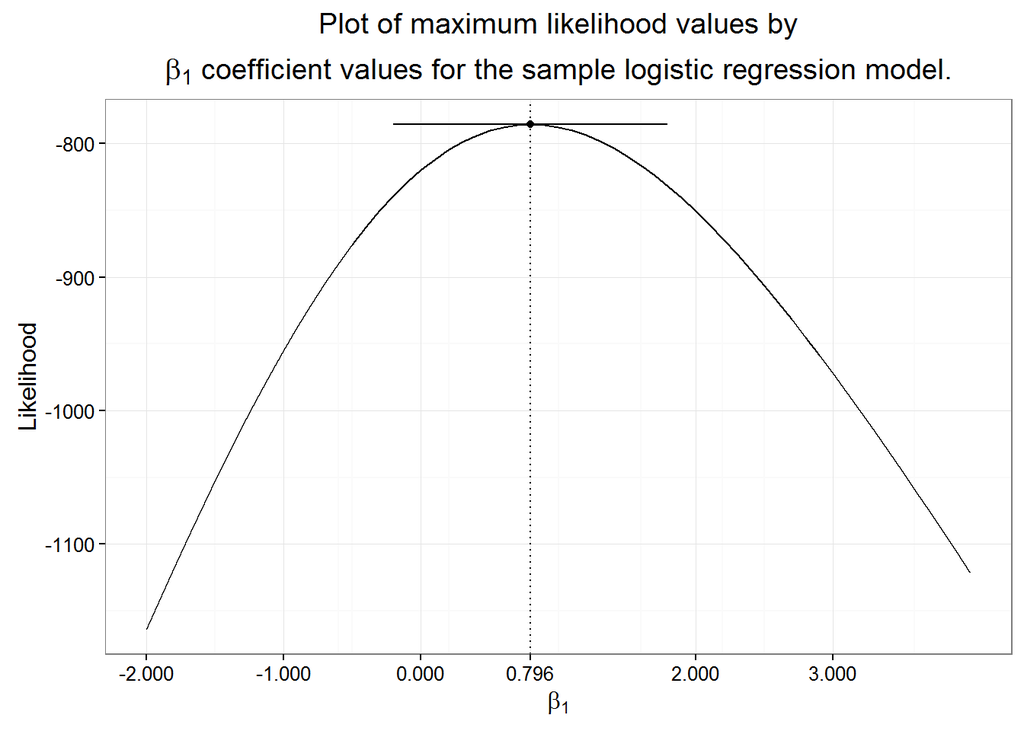

```r
# Plot likelihood
# .........................

LL.logistic.reg.rev = function(beta) {
  lp = x.2 %*% beta
  return(sum(
    b$delta*(log((1+exp(-lp))^(-1))) + (1-b$delta)*(log(1 - (1+exp(-lp))^(-1)))
  )
  )
}

beta.vals = seq(-2, 4, by=0.1)
ll.dat.1 = apply(cbind(rep(o.logit$par[1],length(beta.vals)), beta.vals), 1, LL.logistic.reg.rev) # loop through various values for beta and get likelihood,
# need to start with the estimated intercept...
#head(ll.dat.1)
ll.dat.2 = data.frame(cbind(beta.vals, ll.dat.1))
#head(ll.dat.2)

# see http://stackoverflow.com/questions/29642867/drawing-a-tangent-to-the-plot-and-finding-the-x-intercept-using-r
# for plotting tangents

beta.plot.val = o.logit$par[2]
spl = smooth.spline(ll.dat.2$ll.dat.1 ~ ll.dat.2$beta.vals )
pred0 = predict(spl, x=beta.plot.val, deriv=0);# pred0
pred1 <- predict(spl, x=beta.plot.val, deriv=1);# pred1

# see http://docs.ggplot2.org/current/geom_segment.html

ggplot(data.frame(ll.dat.2), aes(x=beta.vals, y=ll.dat.1)) +
  geom_line() +
  geom_segment(aes(x=pred0$x-1, y=pred0$y,
                   xend=pred0$x+1, yend = pred0$y + pred1$y*1)) +
  geom_point(aes(x=pred0$x, y=pred0$y)) +
  ylab("Likelihood") + xlab(expression(beta[1])) + # see http://astrostatistics.psu.edu/su07/R/html/grDevices/html/plotmath.html
  scale_x_continuous(breaks=c(round(pred1$x,3), c(-2,-1,0,2,3))) +
  geom_vline(xintercept=pred1$x, lty=3) +
  theme_bw() +
  ggtitle(expression(atop("Plot of maximum likelihood values by",  paste(beta[1], " coefficient values for the sample logistic regression model."))))
```

### 0.4.4 Profile ML

#### 0.4.4.1 SAS

```sas
  %let dir=c:\temp;
  libname mle "c:\temp";
  data a; set mle.b; run;

  * profile ML;
  data b;
    set a;
    do b1=0 to 1 by .02, .796442;
        b1idu=b1*idu;
        output;
    end;
  proc sort data=b;
    by b1;
  run; ods select none; run; *Turn off output;
  proc genmod data=b desc;
    by b1;
    model delta=/d=b offset=b1idu;
    ods output modelfit=c;
  run; ods select all; run; *Turn on output;
  data d;
    set c;
    by b1;
    logl=value;
    format logl stderr 10.4;
    if criterion='Log Likelihood' then output;
    keep b1 logl;

  *plot profile loglikelihood;
  *Note: left this part out of the R markdown output;
  * See SAS program titled, "program3.19jan16.sas";

  *approximate derivatives using cubic splines;
  proc expand data=d out=e; convert logl=first/observed=(beginning,derivative); id b1;
  proc expand data=e out=f; convert first=second/observed=(beginning,derivative); id b1;
  data f;
    set f;
    se=sqrt(1/-second);
  proc print data=f noobs;
    var b1 logl first second se;
    title '1st and 2nd approximate derivitives';
```

```
## 1st and 2nd approximate derivitives
##
##    b1            logl         first        second       se
##
## 0.00000     -806.8079       53.6315      -68.3584    0.12095
## 0.02000     -805.7489       52.2643      -68.3559    0.12095
## 0.04000     -804.7173       50.8972      -68.3514    0.12096
## 0.06000     -803.7130       49.5303      -68.3433    0.12096
## 0.08000     -802.7361       48.1635      -68.3308    0.12097
## 0.10000     -801.7865       46.7971      -68.3144    0.12099
## 0.12000     -800.8642       45.4310      -68.2940    0.12101
## 0.14000     -799.9692       44.0653      -68.2695    0.12103
## 0.16000     -799.1016       42.7002      -68.2410    0.12105
## 0.18000     -798.2612       41.3357      -68.2085    0.12108
## 0.20000     -797.4481       39.9719      -68.1720    0.12111
## 0.22000     -796.6623       38.6089      -68.1315    0.12115
## 0.24000     -795.9038       37.2467      -68.0870    0.12119
## 0.26000     -795.1725       35.8854      -68.0385    0.12123
## 0.28000     -794.4683       34.5252      -67.9860    0.12128
## 0.30000     -793.7914       33.1660      -67.9296    0.12133
## 0.32000     -793.1417       31.8080      -67.8692    0.12138
## 0.34000     -792.5191       30.4513      -67.8049    0.12144
## 0.36000     -791.9236       29.0958      -67.7366    0.12150
## 0.38000     -791.3553       27.7418      -67.6644    0.12157
## 0.40000     -790.8140       26.3893      -67.5883    0.12164
## 0.42000     -790.2997       25.0383      -67.5083    0.12171
## 0.44000     -789.8124       23.6890      -67.4245    0.12178
## 0.46000     -789.3521       22.3414      -67.3368    0.12186
## 0.48000     -788.9187       20.9955      -67.2452    0.12195
## 0.50000     -788.5123       19.6516      -67.1498    0.12203
## 0.52000     -788.1327       18.3096      -67.0506    0.12212
## 0.54000     -787.7799       16.9696      -66.9475    0.12222
## 0.56000     -787.4539       15.6317      -66.8407    0.12231
## 0.58000     -787.1546       14.2960      -66.7302    0.12242
## 0.60000     -786.8820       12.9625      -66.6159    0.12252
## 0.62000     -786.6361       11.6314      -66.4979    0.12263
## 0.64000     -786.4167       10.3026      -66.3762    0.12274
## 0.66000     -786.2240        8.9763      -66.2508    0.12286
## 0.68000     -786.0577        7.6526      -66.1217    0.12298
## 0.70000     -785.9178        6.3315      -65.9891    0.12310
## 0.72000     -785.8044        5.0131      -65.8528    0.12323
## 0.74000     -785.7173        3.6974      -65.7129    0.12336
## 0.76000     -785.6565        2.3846      -65.5695    0.12349
## 0.78000     -785.6219        1.0747      -65.4224    0.12363
## 0.79644     -785.6131       -0.0000      -65.2992    0.12375
## 0.80000     -785.6135       -0.2323      -65.2721    0.12378
## 0.82000     -785.6312       -1.5362      -65.1180    0.12392
## 0.84000     -785.6749       -2.8370      -64.9606    0.12407
## 0.86000     -785.7446       -4.1346      -64.7997    0.12423
## 0.88000     -785.8403       -5.4290      -64.6354    0.12438
## 0.90000     -785.9618       -6.7200      -64.4678    0.12455
## 0.92000     -786.1090       -8.0076      -64.2967    0.12471
## 0.94000     -786.2820       -9.2918      -64.1225    0.12488
## 0.96000     -786.4807      -10.5725      -63.9447    0.12505
## 0.98000     -786.7049      -11.8496      -63.7639    0.12523
## 1.00000     -786.9547      -13.1231      -63.5815    0.12541
```

#### 0.4.4.2 R

```r
# Profile ML for beta_1
# ..............................

coef(m.1)[2] # coefficient for beta1 parameter in regression
```

```
##       idu
## 0.7964419
```

```r
b1.prep = c(coef(m.1)[2], seq(0, 1, by=0.02))
#df.3 = expand.grid(df.2[,c("x","y")], b1=b1.prep)

b.3 = cbind(b[rep(1:nrow(b), times=length(b1.prep)),],
             b1=rep(b1.prep, each=nrow(b))) # see http://stackoverflow.com/questions/11693599/alternative-to-expand-grid-for-data-frames

nrow(b)
```

```
## [1] 1164
```

```r
b.3$offset = with(b.3, {b1*idu})
head(b.3)
```

```
##        t delta   art drop id idu white age cd4        b1    offset
## 1  2.245     1    NA    0  1   1     0  44 376 0.7964419 0.7964419
## 2  1.213     1    NA    0  2   1     1  32 392 0.7964419 0.7964419
## 3 10.000     0 1.224    0  3   0     0  44 181 0.7964419 0.0000000
## 4  1.240     1    NA    0  4   1     0  35 526 0.7964419 0.7964419
## 5  7.871     1    NA    0  5   1     1  46 386 0.7964419 0.7964419
## 6  6.593     1 2.207    0  6   0     1  29 285 0.7964419 0.0000000
```

```r
b.3.split = split(b.3, b.3$b1)

glm.3 = lapply(b.3.split, function(z) glm(delta~1, offset=offset, family="binomial", data=z)) # do regression for each unique value of b1. See http://stackoverflow.com/questions/9014308/r-extract-regression-coefficients-from-multiply-regression-via-lapply-command
#coef(glm.3[[1]]) # checking
#deviance(glm.3[[1]]) # -2ll
#logLik(glm.3[[1]]) # ll

glm.3.int = sapply(glm.3, coef) # extract regression coefficients from glm.3 object, just intercepts
head(glm.3.int)
```

```
##    0.(Intercept) 0.02.(Intercept) 0.04.(Intercept) 0.06.(Intercept)
##      -0.01030937      -0.01785253      -0.02539594      -0.03293938
## 0.08.(Intercept)  0.1.(Intercept)
##      -0.04048260      -0.04802539
```

```r
#length(glm.3.int) # check

glm.3.ll = sapply(glm.3, logLik) # extract ll from glm.3 object, just intercepts
head(glm.3.ll)
```

```
##         0      0.02      0.04      0.06      0.08       0.1
## -806.8079 -805.7489 -804.7173 -803.7130 -802.7361 -801.7865
```

```r
hess = data.frame(b1 = sort(b1.prep), logl=glm.3.ll)

# add first and second derivatives
spl = with(hess, smooth.spline(logl ~ b1 ))
pred0 = predict(spl,  deriv=0); #pred0
pred1 = predict(spl, deriv=1); #pred1
pred2 = predict(spl, deriv=2); #pred2

hess$first = pred1$y
hess$second = pred2$y
hess$seb1 = with(hess, sqrt(1/-second))
hess
```

```
##                          b1      logl         first     second      seb1
## 0                 0.0000000 -806.8079  5.322801e+01   1.519556       NaN
## 0.02              0.0200000 -805.7489  5.237241e+01 -87.079513 0.1071623
## 0.04              0.0400000 -804.7173  5.086827e+01 -63.335063 0.1256545
## 0.06              0.0600000 -803.7130  4.953804e+01 -69.687852 0.1197902
## 0.08              0.0800000 -802.7361  4.816145e+01 -67.970995 0.1212937
## 0.1               0.1000000 -801.7865  4.679763e+01 -68.411281 0.1209027
## 0.12              0.1200000 -800.8642  4.543083e+01 -68.268455 0.1210291
## 0.14              0.1400000 -799.9692  4.406538e+01 -68.276771 0.1210218
## 0.16              0.1600000 -799.1016  4.270022e+01 -68.239491 0.1210548
## 0.18              0.1800000 -798.2612  4.133573e+01 -68.209339 0.1210816
## 0.2               0.2000000 -797.4481  3.997191e+01 -68.172194 0.1211146
## 0.22              0.2200000 -796.6623  3.860887e+01 -68.131849 0.1211504
## 0.24              0.2400000 -795.9038  3.724668e+01 -68.087297 0.1211900
## 0.26              0.2600000 -795.1725  3.588542e+01 -68.038817 0.1212332
## 0.28              0.2800000 -794.4683  3.452517e+01 -67.986347 0.1212800
## 0.3               0.3000000 -793.7914  3.316600e+01 -67.929915 0.1213304
## 0.32              0.3200000 -793.1417  3.180801e+01 -67.869528 0.1213843
## 0.34              0.3400000 -792.5191  3.045126e+01 -67.805194 0.1214419
## 0.36              0.3600000 -791.9236  2.909584e+01 -67.736934 0.1215031
## 0.38              0.3800000 -791.3553  2.774182e+01 -67.664736 0.1215679
## 0.4               0.4000000 -790.8140  2.638929e+01 -67.588686 0.1216362
## 0.42              0.4200000 -790.2997  2.503832e+01 -67.508578 0.1217084
## 0.44              0.4400000 -789.8124  2.368898e+01 -67.425046 0.1217838
## 0.46              0.4600000 -789.3521  2.234137e+01 -67.336551 0.1218638
## 0.48              0.4800000 -788.9187  2.099554e+01 -67.246375 0.1219454
## 0.5               0.5000000 -788.5123  1.965158e+01 -67.149061 0.1220338
## 0.52              0.5200000 -788.1327  1.830957e+01 -67.051747 0.1221223
## 0.54              0.5400000 -787.7799  1.696958e+01 -66.947330 0.1222175
## 0.56              0.5600000 -787.4539  1.563170e+01 -66.841302 0.1223144
## 0.58              0.5800000 -787.1546  1.429598e+01 -66.730414 0.1224160
## 0.6               0.6000000 -786.8820  1.296251e+01 -66.616241 0.1225208
## 0.62              0.6200000 -786.6361  1.163137e+01 -66.498183 0.1226295
## 0.64              0.6400000 -786.4167  1.030262e+01 -66.376482 0.1227419
## 0.66              0.6600000 -786.2240  8.976347e+00 -66.251085 0.1228580
## 0.68              0.6800000 -786.0577  7.652615e+00 -66.122038 0.1229778
## 0.7               0.7000000 -785.9178  6.331502e+00 -65.989355 0.1231014
## 0.72              0.7200000 -785.8044  5.013077e+00 -65.853064 0.1232287
## 0.74              0.7400000 -785.7173  3.697415e+00 -65.713183 0.1233598
## 0.76              0.7600000 -785.6565  2.384586e+00 -65.569750 0.1234947
## 0.78              0.7800000 -785.6219  1.074661e+00 -65.422737 0.1236334
## 0.796441938816815 0.7964419 -785.6131  2.588820e-07 -65.299125 0.1237503
## 0.8               0.8000000 -785.6135 -2.322901e-01 -65.272214 0.1237758
## 0.82              0.8200000 -785.6312 -1.536195e+00 -65.118308 0.1239220
## 0.84              0.8400000 -785.6749 -2.836987e+00 -64.960849 0.1240721
## 0.86              0.8600000 -785.7446 -4.134595e+00 -64.799981 0.1242260
## 0.88              0.8800000 -785.8403 -5.428952e+00 -64.635700 0.1243838
## 0.9               0.9000000 -785.9618 -6.719989e+00 -64.468039 0.1245454
## 0.92              0.9200000 -786.1090 -8.007640e+00 -64.297043 0.1247109
## 0.94              0.9400000 -786.2820 -9.291837e+00 -64.122663 0.1248804
## 0.96              0.9600000 -786.4807 -1.057252e+01 -63.945222 0.1250535
## 0.98              0.9800000 -786.7049 -1.184960e+01 -63.763652 0.1252315
## 1                 1.0000000 -786.9547 -1.312306e+01 -63.582082 0.1254101
```

### 0.4.5 Penalized ML, Laplace prior

#### 0.4.5.1 SAS

```sas
  %let dir=c:\temp;
  libname mle "c:\temp";
  data a; set mle.b; run;

*penalized ML, laplace prior;
data a2;
    set a;
    m=0; *prior log OR;
    r=1/8; *prior precision;
    records=1164;
proc nlmixed data=a2;
    parms b0 b1 0;
    mu=1/(1+exp(-(b0+b1*idu)));
    logl=(log(mu)*delta+log(1-mu)*(1-delta))-0.5*r*(b1-m)**2/records;
    model delta~general(logl);
    ods select specifications fitstatistics parameterestimates;
    title "Penalized ML, Laplace prior";
*NOTE: # records is needed because SAS applies the penalty to each record;
*WARNING: Disregard  generated  CI;
run; quit;
```

```
## Penalized ML, Laplace prior
##
## The NLMIXED Procedure
##
##                          Specifications
##
## Data Set                                    WORK.A2
## Dependent Variable                          delta
## Distribution for Dependent Variable         General
## Optimization Technique                      Dual Quasi-Newton
## Integration Method                          None
##
##
##              Fit Statistics
##
## -2 Log Likelihood                 1571.3
## AIC (smaller is better)           1575.3
## AICC (smaller is better)          1575.3
## BIC (smaller is better)           1585.4
##
##
##                               Parameter Estimates
##
##                        Standard
## Parameter   Estimate      Error     DF   t Value   Pr > |t|    Alpha      Lower
##
## b0           -0.3081    0.07513   1164     -4.10     <.0001     0.05    -0.4555
## b1            0.7949     0.1236   1164      6.43     <.0001     0.05     0.5524
##
##       Parameter Estimates
##
## Parameter      Upper    Gradient
##
## b0           -0.1607    4.041E-6
## b1            1.0375    -2.14E-9
```

#### 0.4.5.2 R

```r
LL.logistic.reg.pml = function(beta, x, y, r, m, records) {
  lp = x %*% beta
  mu = 1 / (1+exp(-lp))

  return(-sum(
    (y*log(mu) + (1-y)*log(1 - mu)) - 0.5*r*(beta[2]-m)^2/records
  )
  )
}

# Initial set of parameters
start.beta = c(0, 1) # Arbitrary starting parameters for beta_0 and beta_1

x.2 = cbind(rep(1,length(b$idu)), b$idu) # add an intercept to x matrix

# minimize the (negative) log-likelihood to get the logit fit
o.logit = optim(start.beta, LL.logistic.reg.pml,
                   x = x.2, y = b$delta, r=1/8, m=0, records=1164,
                   method = 'BFGS',
                   hessian=TRUE) # see http://stats.stackexchange.com/questions/81000/calculate-coefficients-in-a-logistic-regression-with-r
o.logit$par
```

```
## [1] -0.3080585  0.7947991
```

### 0.4.6 Penalized ML, near-dogmatic prior

#### 0.4.6.1 SAS

```sas
  %let dir=c:\temp;
  libname mle "c:\temp";
  data a; set mle.b; run;

data a2;
    set a;
    m=0; *prior log OR;
    r=10000; *prior precision;
    records=1164;
proc nlmixed data=a2;
    parms b0 b1 0;
    mu=1/(1+exp(-(b0+b1*idu)));
    logl=(log(mu)*delta+log(1-mu)*(1-delta))-0.5*r*(b1-m)**2/records;
    model delta~general(logl);
    ods select specifications fitstatistics parameterestimates;
    title "Penalized ML, near-dogmatic prior";
run; quit;

*NOTE: # records is needed because SAS applies the penalty to each record;
*WARNING: Disregard  generated  CI;

*Time permitting, try some other priors like in Table 2;
*Also, you can subset the data to make it sparse, then show how penalization helps (comparing against the full data);
```

```
## Penalized ML, near-dogmatic prior
##
## The NLMIXED Procedure
##
##                          Specifications
##
## Data Set                                    WORK.A2
## Dependent Variable                          delta
## Distribution for Dependent Variable         General
## Optimization Technique                      Dual Quasi-Newton
## Integration Method                          None
##
##
##              Fit Statistics
##
## -2 Log Likelihood                 1613.3
## AIC (smaller is better)           1617.3
## AICC (smaller is better)          1617.3
## BIC (smaller is better)           1627.4
##
##
##                               Parameter Estimates
##
##                        Standard
## Parameter   Estimate      Error     DF   t Value   Pr > |t|    Alpha      Lower
##
## b0          -0.01232    0.05874   1164     -0.21     0.8339     0.05    -0.1276
## b1          0.005327   0.009966   1164      0.53     0.5931     0.05   -0.01423
##
##       Parameter Estimates
##
## Parameter      Upper    Gradient
##
## b0            0.1029    -2.43E-8
## b1           0.02488    -4.31E-9
```

#### 0.4.6.2 R

```r
# minimize the (negative) log-likelihood to get the logit fit
o.logit = optim(start.beta, LL.logistic.reg.pml,
                   x = x.2, y = b$delta, r=1e4, m=0, records=1164,
                   method = 'BFGS',
                   hessian=TRUE) # see http://stats.stackexchange.com/questions/81000/calculate-coefficients-in-a-logistic-regression-with-r
o.logit$par
```

```
## [1] -0.01231835  0.00532673
```

Assigned reading

1. Cole SR, Chu H, Greenland S. Maximum Likelihood, Profile Likelihood, and Penalized Likelihood: A Primer. *Am. J. Epidemiol.* [electronic article]. 2014;179(2):252–260. (http://aje.oxfordjournals.org/cgi/doi/10.1093/aje/kwt245)